# Practical Machine learning course Project

Mukund

12 January 2018

## I. Overview

The main goal of the project is to predict the manner in which 6 participants performed some exercise as described below. This is the “classe” variable in the training set. The machine learning algorithm described here is applied to the 20 test cases available in the test data and the predictions are submitted in appropriate format.

## 2. Background Using devices such as Jawbone Up, Nike FuelBand, and Fitbit it is now possible to collect a large amount of data about personal activity relatively inexpensively. These type of devices are part of the quantified self movement - a group of enthusiasts who take measurements about themselves regularly to improve their health, to find patterns in their behavior, or because they are tech geeks. One thing that people regularly do is quantify how much of a particular activity they do, but they rarely quantify how well they do it. In this project, your goal will be to use data from accelerometers on the belt, forearm, arm, and dumbell of 6 participants. They were asked to perform barbell lifts correctly and incorrectly in 5 different ways. More information is available from the website here: http://groupware.les.inf.puc-rio.br/har (see the section on the Weight Lifting Exercise Dataset).

## 3. Data Loading and Exploratory Analysis

### 3A. Loading Data and treating different missing values

```r
## Loading and preprocessing the data. Treat "#DIV/0!",blank, string "NA"as missing values.
HARdatatrain <- read.csv("pml-training.csv",na.strings=c("NA","#DIV/0!",""))
HARdatatest <- read.csv("pml-testing.csv", na.strings=c("NA","#DIV/0!",""))
```

### 3B.Loading different Librarirs

```r
## Loading Libraries
library(ggplot2)
library(caret)
library(rpart)
library(rpart.plot)
library(RColorBrewer)
library(rattle)
library(corrplot)
```

### 3C.Data Cleaning

```r
## ## Since data after Column 8 is all numeric, Cast these column as Numeric
for(i in c(8:ncol(HARdatatrain)-1)) {HARdatatrain[,i] = as.numeric(as.character(HARdatatrain[,i]))}
for(i in c(8:ncol(HARdatatest)-1)) {HARdatatest[,i] = as.numeric(as.character(HARdatatest[,i]))}

## Remove Nas
AllNAs    <- sapply(HARdatatrain, function(x) mean(is.na(x))) > 0.95
HARdatatrain <- HARdatatrain[, AllNAs==FALSE]
HARdatatest  <- HARdatatest [, AllNAs==FALSE]

## Remove Near zero variances
NZV <- nearZeroVar(HARdatatrain)
HARdatatrain<- HARdatatrain[, -NZV]
HARdatatest <- HARdatatest[, -NZV]

# remove identification only variables (columns 1 to 5)
HARdatatrain <- HARdatatrain[, -(1:5)]
HARdatatest <- HARdatatest[, -(1:5)]
```

## 4. Parttion the Data set into Training and Testing

```r
## partition the training data
HARinTrain <- createDataPartition(y=HARdatatrain$classe,p=0.75, list=FALSE)
HARtraining <- HARdatatrain[HARinTrain,]
HARtesting <- HARdatatrain[-HARinTrain,]
```

## 6. Finding Correlations between different features to select which is most relavent to model further.

### 6A. Plotting Correlation Plot and correlation thershold (.85) Analysis

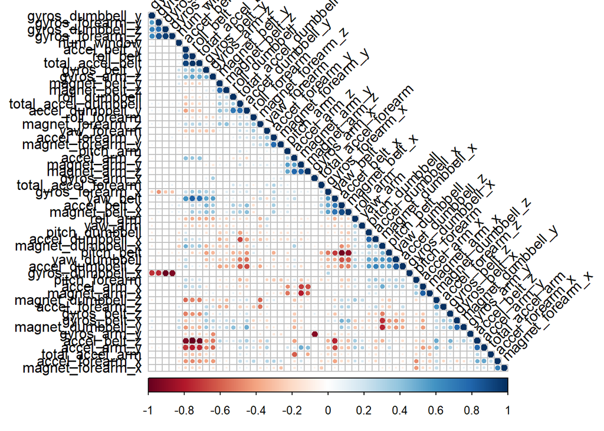

```r
corMatrix <- cor(HARtraining[, -54])
corrplot(corMatrix, order = "hclust", type = "lower", tl.srt = 45, tl.col = rgb(0, 0, 0))
```

```r
corrmt1 <- findCorrelation(corMatrix, cutoff = 0.85, names = TRUE)
length(corrmt1)
```

```
## [1] 9
```

Let us do some more exploration by plotting density plot to see if there are overlaps in features. ## 6B. Density plotting for overlap.

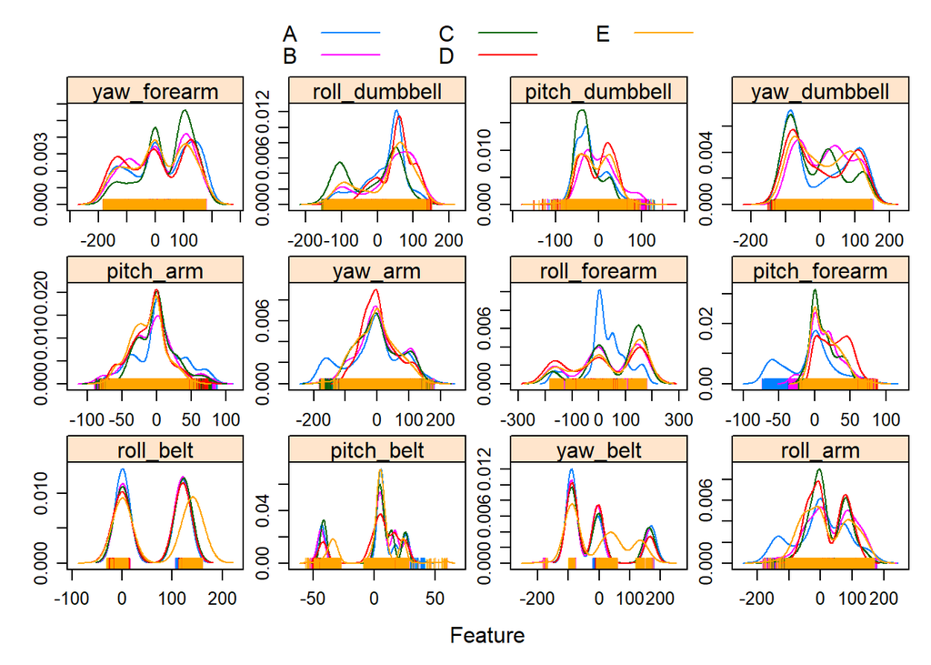

```r
## Extract features which are uncorrelated for feature plotting.
plotfeatures <- c("roll_belt", "pitch_belt", "yaw_belt", "roll_arm", "pitch_arm",
              "yaw_arm", "roll_forearm", "pitch_forearm", "yaw_forearm", "roll_dumbbell",
              "pitch_dumbbell", "yaw_dumbbell")
class_feature <- c("classe")
plottrainData <- HARtraining[, c(plotfeatures, class_feature)]
plottestData <- HARtesting[, plotfeatures]


## Do basic Exploratory plots
featurePlot(x = plottrainData[, plotfeatures],
            y = plottrainData[, class_feature],
            plot = "density",
            scales = list(x = list(relation="free"),
                          y = list(relation="free")),
            adjust = 1.5,
            pch = "|",
            auto.key = list(columns = 3))
```

## 7. Preprocessing and Standardization using cross validation

```r
## Cross validation
TrainControl <- trainControl(method = "cv", number = 4)
```

## 8. Fitting and predicting Different Model

### 8A. We will start with a Decision tree Model first.

```r
## fit a decision tree model first
modFit1 <- rpart(classe ~ ., data=HARtraining, method="class")
predict1 <- predict(modFit1, HARtesting, type = "class")
confusionMatrix(predict1, HARtesting$classe)
```

```
## Confusion Matrix and Statistics
##
##           Reference
## Prediction    A    B    C    D    E
##          A 1236  175   27   43   39
##          B   51  558   71   63   85
##          C   17   66  622  125   90
##          D   72   95  101  483   57
##          E   19   55   34   90  630
##
## Overall Statistics
##
##                Accuracy : 0.7196
##                  95% CI : (0.7068, 0.7322)
##     No Information Rate : 0.2845
##     P-Value [Acc > NIR] : < 2.2e-16
##
##                   Kappa : 0.6444
##  Mcnemar's Test P-Value : < 2.2e-16
##
## Statistics by Class:
##
##                      Class: A Class: B Class: C Class: D Class: E
## Sensitivity            0.8860   0.5880   0.7275  0.60075   0.6992
## Specificity            0.9191   0.9317   0.9264  0.92073   0.9505
## Pos Pred Value         0.8132   0.6739   0.6761  0.59777   0.7609
## Neg Pred Value         0.9530   0.9041   0.9415  0.92163   0.9335
## Prevalence             0.2845   0.1935   0.1743  0.16395   0.1837
## Detection Rate         0.2520   0.1138   0.1268  0.09849   0.1285
## Detection Prevalence   0.3100   0.1688   0.1876  0.16476   0.1688
## Balanced Accuracy      0.9025   0.7599   0.8269  0.76074   0.8249
```

### 8B. We will now fit a Random Forest Model.

```r
modFit2 <- train(classe ~ ., data=HARtraining, method="rf",trControl=TrainControl)
modFit2$finalModel
```

```
##
## Call:
##  randomForest(x = x, y = y, mtry = param$mtry)
##                Type of random forest: classification
##                      Number of trees: 500
## No. of variables tried at each split: 27
##
##         OOB estimate of  error rate: 0.19%
## Confusion matrix:
##      A    B    C    D    E  class.error
## A 4183    1    0    0    1 0.0004778973
## B    7 2838    3    0    0 0.0035112360
## C    0    5 2562    0    0 0.0019477990
## D    0    0    7 2405    0 0.0029021559
## E    0    1    0    3 2702 0.0014781966
```

```r
predictRandForest <- predict(modFit2, newdata=HARtesting)
confusionMatrix(predictRandForest, HARtesting$classe)
```

```
## Confusion Matrix and Statistics
##
##           Reference
## Prediction    A    B    C    D    E
##          A 1395    1    0    0    0
##          B    0  946    0    0    0
##          C    0    1  855    3    0
##          D    0    1    0  800    0
##          E    0    0    0    1  901
##
## Overall Statistics
##
##                Accuracy : 0.9986
##                  95% CI : (0.9971, 0.9994)
##     No Information Rate : 0.2845
##     P-Value [Acc > NIR] : < 2.2e-16
##
##                   Kappa : 0.9982
##  Mcnemar's Test P-Value : NA
##
## Statistics by Class:
##
##                      Class: A Class: B Class: C Class: D Class: E
## Sensitivity            1.0000   0.9968   1.0000   0.9950   1.0000
## Specificity            0.9997   1.0000   0.9990   0.9998   0.9998
## Pos Pred Value         0.9993   1.0000   0.9953   0.9988   0.9989
## Neg Pred Value         1.0000   0.9992   1.0000   0.9990   1.0000
## Prevalence             0.2845   0.1935   0.1743   0.1639   0.1837
## Detection Rate         0.2845   0.1929   0.1743   0.1631   0.1837
## Detection Prevalence   0.2847   0.1929   0.1752   0.1633   0.1839
## Balanced Accuracy      0.9999   0.9984   0.9995   0.9974   0.9999
```

## 9.Comparing both, we choose Random Forest Model to finally predict the test data

```r
predicTest<- predict(modFit2, HARdatatest)
predicTest
```

```
##  [1] B A B A A E D B A A B C B A E E A B B B
## Levels: A B C D E
```

## 10. Finally We write the result into seperate files.

```r
## print to respective files
write_files = function(x){
       n = length(x)
      for(i in 1:n){
             filename = paste0("id_",i,".txt")
           write.table(x[i],file=filename,quote=FALSE,row.names=FALSE,col.names=FALSE)
        }
   }
write_files(predicTest)
```